# PDI Classificadores KNN

## Classificadores KNN

```python
#!pip install matplotlib
import cv2
import numpy as np
import matplotlib.pyplot as plt
import math
import pickle
```

### OCR of Hand-written Digits

https://docs.opencv.org/3.4.2/d8/d4b/tutorial_py_knn_opencv.html

Our goal is to build an application which can read the handwritten digits. For this we need some train_data and test_data. OpenCV comes with an image digits.png (in the folder opencv/samples/data/) which has 5000 handwritten digits (500 for each digit). Each digit is a 20x20 image. So our first step is to split this image into 5000 different digits. For each digit, we flatten it into a single row with 400 pixels. That is our feature set, ie intensity values of all pixels. It is the simplest feature set we can create. We use first 250 samples of each digit as train_data, and next 250 samples as test_data. So let's prepare them first.

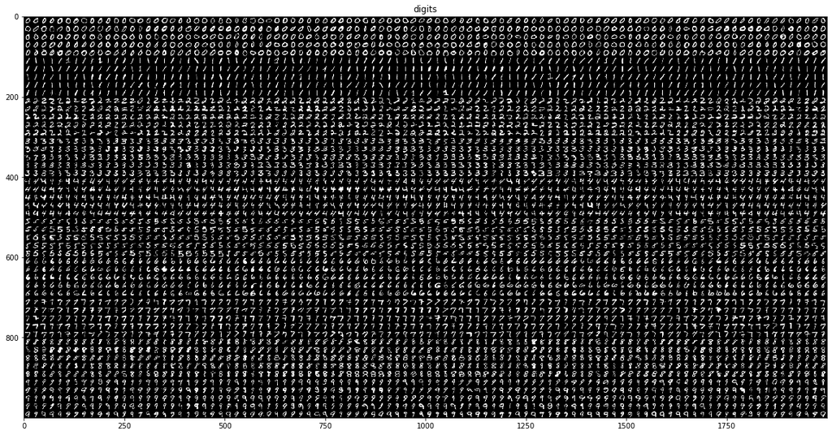

```python
test = cv2.imread("data\digits.png")
plt.figure(figsize=(20,20)); plt.title("digits"); fig = plt.imshow(test,"gray")
```

### The Chars74K dataset

http://www.ee.surrey.ac.uk/CVSSP/demos/chars74k/

EnglishFnt.tgz (51.1 MB): characters from computer fonts with 4 variations (combinations of italic, bold and normal).

In the English language, Latin script (excluding accents) and Hindu-Arabic numerals are used. For simplicity we call this the "English" characters set. Our dataset consists of:

[output not shown]

[output not shown]

[figure not shown]

```python
###Preparando Novo Dataset
if False:
    import glob
    import pickle
    import cv2
    import numpy

    images = []
    for i in range(62):
        i+=1
        if i<10: digit = "0"+str(i)
        else: digit = str(i)
        #print("data\English\Fnt\Sample0"+digit+"\*.png")
        images.append([cv2.imread(file) for file in glob.glob("data\English\Fnt\Sample0"+digit+"\*.png")] )

    images = np.array(images)

    #Testando
    print(images.shape) #(62, 1016, 128, 128, 3) 62 classes
    plt.figure(figsize=(2,2)); plt.title("test"); fig = plt.imshow(images[0,0,:,:,:],"gray")
```

[output not shown]

[figure not shown]

```python
###Abrindo e testando dataset

#Salvando dataset
if False:
    with open('data\knn_images.pkl', 'wb') as data_file:
        pickle.dump(images, data_file)

#Abrindo dataset
with open('data\knn_images.pkl', 'rb') as data_file:
    knn_images = pickle.load(data_file)

#Testando
plt.figure(figsize=(2,2)); plt.title("test"); fig = plt.imshow(knn_images[0,0,:,:,:],"gray")
print(knn_images.shape)
data = knn_images.copy()
```

```
(20, 20)
```

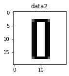

```python
###Modificando para formato certo

data2 = np.zeros([62,1016,20,20])
for c in range(62):
    for i in range(1016):
        img = data[c,i]
        img = cv2.cvtColor(img,cv2.COLOR_BGR2GRAY)
        img = cv2.resize(img ,(20,20), interpolation = cv2.INTER_NEAREST)
        data2[c,i] = img

plt.figure(figsize=(2,2)); plt.title("data2"); fig = plt.imshow(data2[0,0],"gray")
data2[0,0].shape
#data_processed[:,:,:,:,0] = [ cv2.cvtColor(img,cv2.COLOR_BGR2GRAY) for img in loaded[:,:] ]

#img = cv2.resize(img ,(20,20), interpolation = cv2.INTER_NEAREST)
#img = img.reshape(-1,400).astype(np.float32)
```

#### Treinando para o dataset inteiro

```python
data2.shape # (62,1016,20,20)

# Now we prepare train_data and test_data.
train = data2[:,:508].reshape(-1,400).astype(np.float32) # Size = (2500,400) 400 pixeis, 2500 números
test  = data2[:,508:].reshape(-1,400).astype(np.float32) # Size = (2500,400)
# Create labels for train and test data
k = np.arange(62)
train_labels = np.repeat(k,508)[:,np.newaxis] #list of lists containing one class each
test_labels = train_labels.copy()
# Initiate kNN, train the data, then test it with test data for k=1
knn = cv.ml.KNearest_create()
knn.train(train, cv.ml.ROW_SAMPLE, train_labels)
ret,result,neighbours,dist = knn.findNearest(test,k=5)
# Now we check the accuracy of classification
# For that, compare the result with test_labels and check which are wrong
matches = result==test_labels
correct = np.count_nonzero(matches)
accuracy = correct*100.0/result.size
print( accuracy ) #75
```

```
75.38417576835154
```

```python
list_digit = [str(i) for i in range(10)]
list_upper = [chr(i) for i in range(ord('A'),ord('Z')+1)]
list_lower = [chr(i) for i in range(ord('a'),ord('z')+1)]
classes = list_digit+list_upper+list_lower

# save the data
np.savez('data\knn_data.npz',train=train, train_labels=train_labels, classes=classes)
# Now load the data
with np.load('data\knn_data.npz') as data:
    print( data.files )
    train = data['train']
    train_labels = data['train_labels']
    knn_classes = data['classes']
```

```
['train', 'train_labels', 'classes']
```

#### Treinando Números Apenas

```python
import cv2
data2.shape # (62,1016,20,20)
data3 = data2[0:10, :,:,:]

# Now we prepare train_data and test_data.
train = data3[:,:508].reshape(-1,400).astype(np.float32) # Size = (2500,400) 400 pixeis, 2500 números
test  = data3[:,508:].reshape(-1,400).astype(np.float32) # Size = (2500,400)
# Create labels for train and test data
k = np.arange(10)
train_labels = np.repeat(k,508)[:,np.newaxis] #list of lists containing one class each
test_labels = train_labels.copy()
# Initiate kNN, train the data, then test it with test data for k=1
knn = cv.ml.KNearest_create()
knn.train(train, cv.ml.ROW_SAMPLE, train_labels)
ret,result,neighbours,dist = knn.findNearest(test,k=5)
# Now we check the accuracy of classification
# For that, compare the result with test_labels and check which are wrong
matches = result==test_labels
correct = np.count_nonzero(matches)
accuracy = correct*100.0/result.size
print( accuracy ) #75
```

```
89.74409448818898
```

```python
list_digit = [str(i) for i in range(10)]
classes = list_digit

# save the data
np.savez('data\knn_data_numbers.npz',train=train, train_labels=train_labels, classes=classes)
# Now load the data
with np.load('data\knn_data_numbers.npz') as data:
    print( data.files )
    train = data['train']
    train_labels = data['train_labels']
    knn_classes = data['classes']
```

```
['train', 'train_labels', 'classes']
```

#### Treinando Maiúsculas Apenas

```python
data2.shape # (62,1016,20,20)
data3 = data2[10:36, :,:,:]

# Now we prepare train_data and test_data.
train = data3[:,:508].reshape(-1,400).astype(np.float32) # Size = (2500,400) 400 pixeis, 2500 números
test  = data3[:,508:].reshape(-1,400).astype(np.float32) # Size = (2500,400)
# Create labels for train and test data
k = np.arange(26)
train_labels = np.repeat(k,508)[:,np.newaxis] #list of lists containing one class each
test_labels = train_labels.copy()
# Initiate kNN, train the data, then test it with test data for k=1
knn = cv.ml.KNearest_create()
knn.train(train, cv.ml.ROW_SAMPLE, train_labels)
ret,result,neighbours,dist = knn.findNearest(test,k=5)
# Now we check the accuracy of classification
# For that, compare the result with test_labels and check which are wrong
matches = result==test_labels
correct = np.count_nonzero(matches)
accuracy = correct*100.0/result.size
print( accuracy ) #75
```

```
84.58509993943065
```

```python
list_upper = [chr(i) for i in range(ord('A'),ord('Z')+1)]
classes = list_upper

# save the data
np.savez('data\knn_data_letters.npz',train=train, train_labels=train_labels, classes=classes)
# Now load the data
with np.load('data\knn_data_letters.npz') as data:
    print( data.files )
    train = data['train']
    train_labels = data['train_labels']
    knn_classes = data['classes']
```

```
['train', 'train_labels', 'classes']
```

#### Treinando Distinguir Letras e caracteres

```python
data2.shape # (62,1016,20,20)
data3 = data2[0:36, :,:,:]

# Now we prepare train_data and test_data.
train = data3[:,:508].reshape(-1,400).astype(np.float32) # Size = (2500,400) 400 pixeis, 2500 números
test  = data3[:,508:].reshape(-1,400).astype(np.float32) # Size = (2500,400)
# Create labels for train and test data
k = [0 for i in range(10)]+[1 for i in range(26)]
k = np.array(k)
train_labels = np.repeat(k,508)[:,np.newaxis] #list of lists containing one class each
test_labels = train_labels.copy()
# Initiate kNN, train the data, then test it with test data for k=1
knn = cv.ml.KNearest_create()
knn.train(train, cv.ml.ROW_SAMPLE, train_labels)
ret,result,neighbours,dist = knn.findNearest(test,k=5)
# Now we check the accuracy of classification
# For that, compare the result with test_labels and check which are wrong
matches = result==test_labels
correct = np.count_nonzero(matches)
accuracy = correct*100.0/result.size
print( accuracy ) #75
```

```
94.76159230096238
```

```python
classes = list(k)

# save the data
np.savez('data\knn_data_classify.npz',train=train, train_labels=train_labels, classes=classes)
# Now load the data
with np.load('data\knn_data_classify.npz') as data:
    print( data.files )
    train = data['train']
    train_labels = data['train_labels']
    knn_classes = data['classes']
```

```
['train', 'train_labels', 'classes']
```

#### Criando Funções para Utilizar os Classificadores

```python
def knn_load(file_path):
    with np.load(file_path) as data:
        #print( data.files )
        train = data['train']
        train_labels = data['train_labels']
        knn_classes = data['classes']

    knn = cv2.ml.KNearest_create()
    knn.train(train, cv2.ml.ROW_SAMPLE, train_labels)
    return knn, knn_classes

def knn_classify(img, model, knn_classes):
    img = cv2.cvtColor(img,cv2.COLOR_BGR2GRAY)
    try:
        img_resized = cv2.resize(img ,(20,20), interpolation = cv2.INTER_NEAREST)
    except:
        return "#"
    #if np.mean(img) < 127:
    #    img = 255-img
        #ret, img = cv2.threshold(img,0,255,cv2.THRESH_BINARY_INV+cv2.THRESH_OTSU)
    img_reshaped = img_resized.reshape(-1,400).astype(np.float32)
    ret,result,neighbours,dist = model.findNearest(img_reshaped,k=5)

    plt.figure(figsize=(4,4))
    plt.subplot(121); plt.title("img"); plt.imshow(img,"gray")
    plt.subplot(122); plt.title(knn_classes[int(result)]); plt.imshow(img_resized,"gray")
    plt.show()
    return knn_classes[int(result)]
```

#### Testando Classificadores

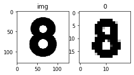

```
Número ou Letra?  0
```

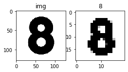

```
Qual número?  8
```

```python
#Abrindo modelos
m_classify, c_classify = knn_load('data\knn_data_classify.npz')
m_numbers, c_numbers = knn_load('data\knn_data_numbers.npz')

#Aplicando
test = cv2.imread("data\eigth.png")
result = knn_classify(test,m_classify, c_classify)
print("Número ou Letra? ", result)
result = knn_classify(test,m_numbers, c_numbers)
print("Qual número? ", result)
```

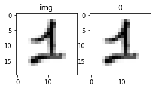

```
Número ou Letra?  0
```

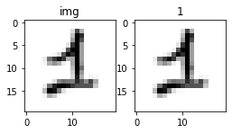

```
Qual número?  1
```

```python
#Aplicando

test = cv2.imread("data\digits.png")[100:120,100:120]
test = 255-test
result = knn_classify(test,m_classify, c_classify)
print("Número ou Letra? ", result)
result = knn_classify(test,m_numbers, c_numbers)
print("Qual número? ", result)
```